# Final_project-DCW

David Austin, Collin, Wil Nahra

2025-04-15

## Introduction

**Diamonds Overview:** The diamonds dataset focuses on the different qualities of commercial diamonds (carat, color, price, etc.). There are 53940 entries.

## Variables

**price:** The diamond’s price in US dollars

**carat:** The diamond’s weight

**cut:** The quality of the diamond’s cut (Fair, Good, Very Good, Premium, Ideal)

**color:** The color of the diamond, from D(best) to J(worst)

**clarity:** The clearness of the diamond (I1(worst), SI2, SI1, VS2, VS1, VVS2, VVS1, IF(best))

**x,y,z:** The length, width, and depth of the diamond respectively (in mm)

**depth:** The total depth percentage (z/mean(x,y))

**table:** The wide of the top of the diamond relative to its widest point

## Specific Questions

**Color and Price:** The largest question we hope to answer with this dataset is concluding whether the color of a diamond is correlated to its market price. We will answer this by comparing the variables in multiple different ways. Firstly, we show various graphs comparing different variables to price in order to draw a general trend. Then, we will create a box plot comparing color and price to show the spread of data for each color in order to see which color tends to be the most valuable. Then we show a statistics table with data (mean price, count, color, standard deviation price) in order to show empirical proof of our findings. Lastly, we show a p-table to draw whether or not this is caused entirely by chance.

```r
library(ggplot2)
data(diamonds)
str(diamonds)
```

```
## tibble [53,940 × 10] (S3: tbl_df/tbl/data.frame)
##  $ carat  : num [1:53940] 0.23 0.21 0.23 0.29 0.31 0.24 0.24 0.26 0.22 0.23 ...
##  $ cut    : Ord.factor w/ 5 levels "Fair"<"Good"<..: 5 4 2 4 2 3 3 3 1 3 ...
##  $ color  : Ord.factor w/ 7 levels "D"<"E"<"F"<"G"<..: 2 2 2 6 7 7 6 5 2 5 ...
##  $ clarity: Ord.factor w/ 8 levels "I1"<"SI2"<"SI1"<..: 2 3 5 4 2 6 7 3 4 5 ...
##  $ depth  : num [1:53940] 61.5 59.8 56.9 62.4 63.3 62.8 62.3 61.9 65.1 59.4 ...
##  $ table  : num [1:53940] 55 61 65 58 58 57 57 55 61 61 ...
##  $ price  : int [1:53940] 326 326 327 334 335 336 336 337 337 338 ...
##  $ x      : num [1:53940] 3.95 3.89 4.05 4.2 4.34 3.94 3.95 4.07 3.87 4 ...
##  $ y      : num [1:53940] 3.98 3.84 4.07 4.23 4.35 3.96 3.98 4.11 3.78 4.05 ...
##  $ z      : num [1:53940] 2.43 2.31 2.31 2.63 2.75 2.48 2.47 2.53 2.49 2.39 ...
```

```r
summary(diamonds)
```

```
##      carat               cut        color        clarity          depth
##  Min.   :0.2000   Fair     : 1610   D: 6775   SI1    :13065   Min.   :43.00
##  1st Qu.:0.4000   Good     : 4906   E: 9797   VS2    :12258   1st Qu.:61.00
##  Median :0.7000   Very Good:12082   F: 9542   SI2    : 9194   Median :61.80
##  Mean   :0.7979   Premium  :13791   G:11292   VS1    : 8171   Mean   :61.75
##  3rd Qu.:1.0400   Ideal    :21551   H: 8304   VVS2   : 5066   3rd Qu.:62.50
##  Max.   :5.0100                     I: 5422   VVS1   : 3655   Max.   :79.00
##                                     J: 2808   (Other): 2531
##      table           price             x                y
##  Min.   :43.00   Min.   :  326   Min.   : 0.000   Min.   : 0.000
##  1st Qu.:56.00   1st Qu.:  950   1st Qu.: 4.710   1st Qu.: 4.720
##  Median :57.00   Median : 2401   Median : 5.700   Median : 5.710
##  Mean   :57.46   Mean   : 3933   Mean   : 5.731   Mean   : 5.735
##  3rd Qu.:59.00   3rd Qu.: 5324   3rd Qu.: 6.540   3rd Qu.: 6.540
##  Max.   :95.00   Max.   :18823   Max.   :10.740   Max.   :58.900
##
##        z
##  Min.   : 0.000
##  1st Qu.: 2.910
##  Median : 3.530
##  Mean   : 3.539
##  3rd Qu.: 4.040
##  Max.   :31.800
##
```

## Exploratory Data Analysis

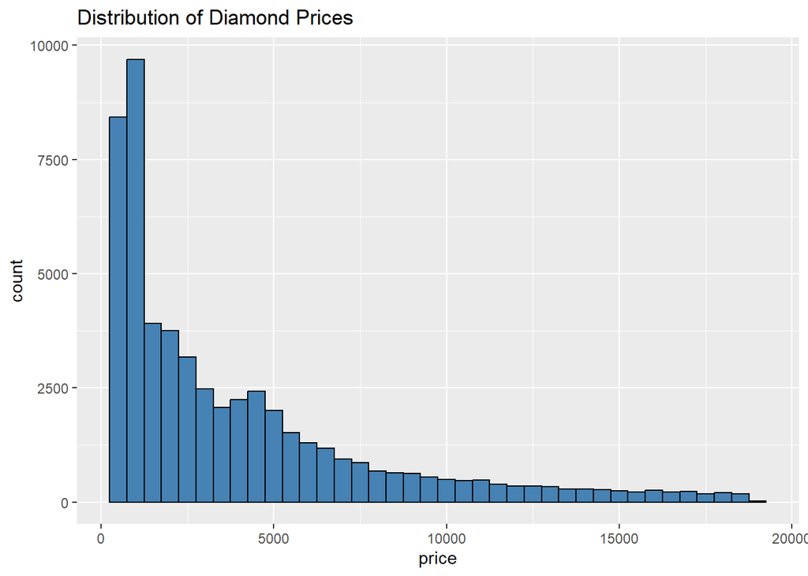

```r
library(dplyr)

# Histogram of Price
ggplot(diamonds, aes(x = price)) +
  geom_histogram(binwidth = 500, fill = "steelblue", color = "black") +
  ggtitle("Distribution of Diamond Prices")
```

The Histogram above shows the price diamonds from $0 to $20,000 and their popularity. Based on this histogram, we can see visually that the most popular price when it comes to popularity is around the $500 - $1000 range with a steady decrease as the price increases

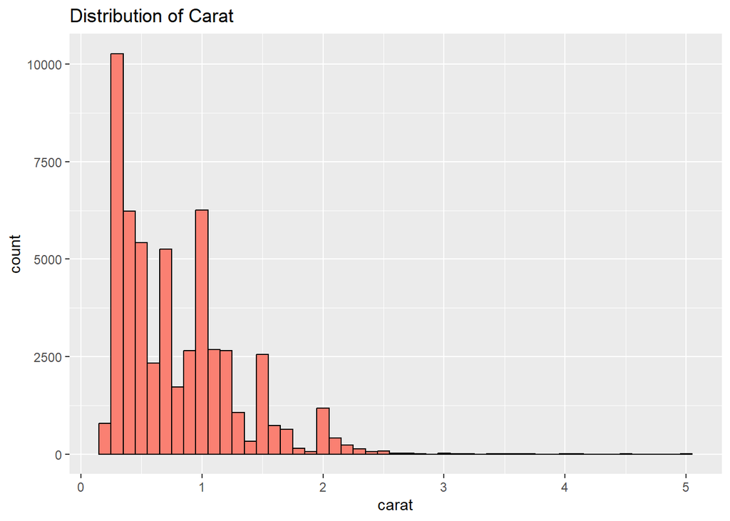

```r
# Histogram of Carat
ggplot(diamonds, aes(x = carat)) +
  geom_histogram(binwidth = 0.1, fill = "salmon", color = "black") +
  ggtitle("Distribution of Carat")
```

This Histogram shows the distribution of carats from 0.1 to 5.0 carats and there popularity/count ranging from 0 to over 10,000. Visualizing the data, we can see when is comes to carat distribution, 0.3 is considered the most popular with a decrease going forward with noticeable burst at the 0.7 and 1.0.

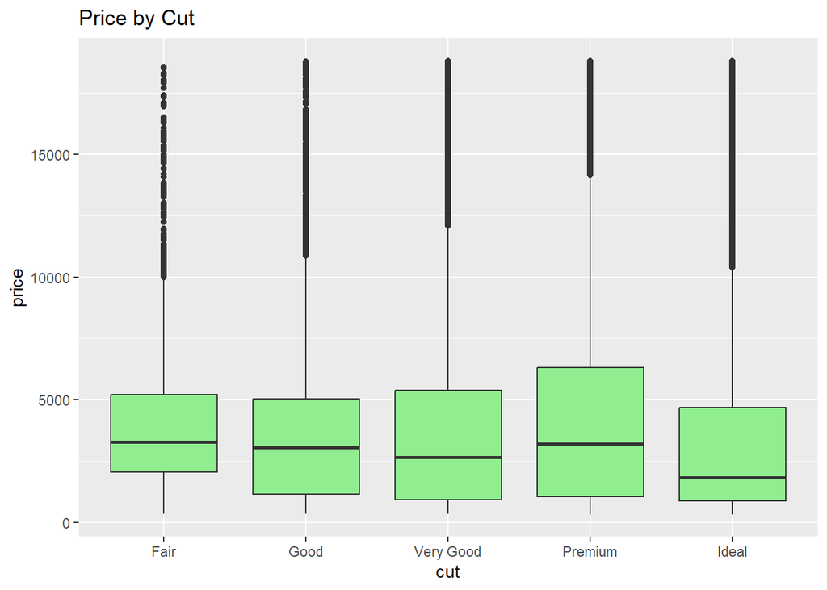

```r
# Boxplot of Price by Cut
ggplot(diamonds, aes(x = cut, y = price)) +
  geom_boxplot(fill = "lightgreen") +
  ggtitle("Price by Cut")
```

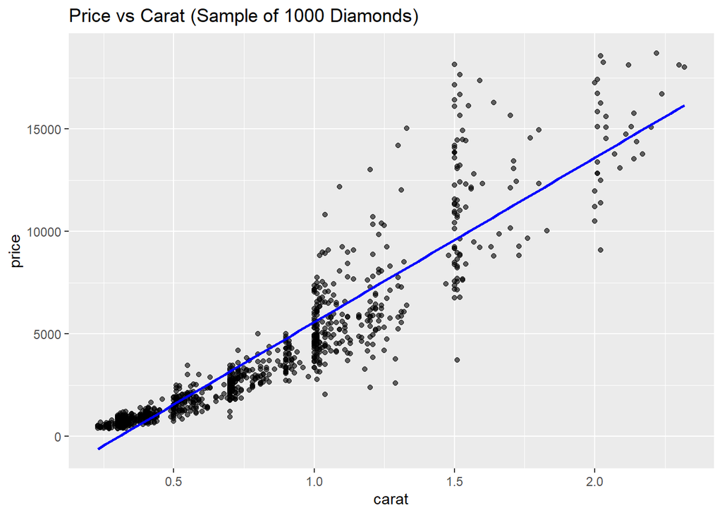

```r
# Scatterplot of Price vs Carat
set.seed(123)
diamonds_sample <- diamonds[sample(nrow(diamonds), 1000), ]

ggplot(diamonds_sample, aes(x = carat, y = price)) +
  geom_point(alpha = 0.6) +
  geom_smooth(method = "lm", se = FALSE, color = "blue") +
  ggtitle("Price vs Carat (Sample of 1000 Diamonds)")
```

This scatterplot visualizes the relationship between diamond price and carat weight for a random sample of 1,000 diamonds from the diamonds dataset. The plot reveals a strong positive linear relationship: as carat increases, price generally rises. While the trend is clear, there’s noticeable spread around the line, especially at certain carat sizes, indicating some variability in pricing even among diamonds of the same weight—likely due to factors like cut, color, and clarity.

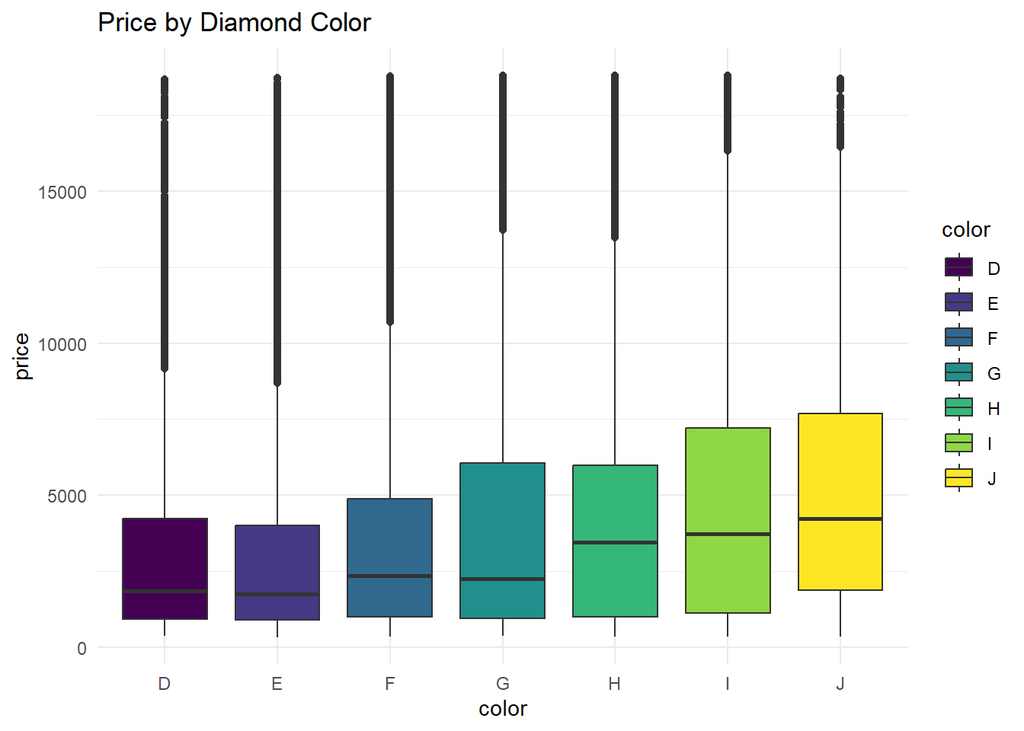

```r
# Boxplot of Price by Color
ggplot(diamonds, aes(x = color, y = price, fill = color)) +
  geom_boxplot() +
  ggtitle("Price by Diamond Color") +
  theme_minimal()
```

This boxplot visualizes the distribution of diamond prices across different color grades from the diamonds dataset. The x-axis represents distinct diamond colors (D–J), while the y-axis displays price, ranging up to 20,000. Each box encapsulates the interquartile range. The plot reveals noticeable differences in diamond pricing based on color. Certain color grades exhibit higher median prices, suggesting a potential market preference or rarity effect. The variability in price also differs by color, with some showing a wider range while others are more consistent.

```r
# Statistical Analysis

# Grouped summary statistics by color: mean price, SD(standard deviation), and count
# Helps us see general trends—e.g., which color grades are associated with higher or lower prices
diamonds %>%
  group_by(color) %>%
  summarise(mean_price = mean(price), sd_price = sd(price), count = n())
```

| color | mean_price | sd_price | count |
| --- | --- | --- | --- |
| D | 3169.954 | 3356.591 | 6775 |
| E | 3076.752 | 3344.159 | 9797 |
| F | 3724.886 | 3784.992 | 9542 |
| G | 3999.136 | 4051.103 | 11292 |
| H | 4486.669 | 4215.944 | 8304 |
| I | 5091.875 | 4722.388 | 5422 |
| J | 5323.818 | 4438.187 | 2808 |

```r
# Calculate 95% confidence intervals for mean price by color
library(dplyr)

color_ci <- diamonds %>%
  group_by(color) %>%
  summarise(
    mean_price = mean(price),
    sd_price = sd(price),
    n = n(),
    se = sd_price / sqrt(n),
    lower_ci = mean_price - 1.96 * se,
    upper_ci = mean_price + 1.96 * se
  )

# Print the confidence interval table
color_ci
```

| color | mean_price | sd_price | n | se | lower_ci | upper_ci |
| --- | --- | --- | --- | --- | --- | --- |
| D | 3169.954 | 3356.591 | 6775 | 40.77968 | 3090.026 | 3249.882 |
| E | 3076.752 | 3344.159 | 9797 | 33.78628 | 3010.531 | 3142.974 |
| F | 3724.886 | 3784.992 | 9542 | 38.74764 | 3648.941 | 3800.832 |
| G | 3999.136 | 4051.103 | 11292 | 38.12307 | 3924.414 | 4073.857 |
| H | 4486.669 | 4215.944 | 8304 | 46.26485 | 4395.990 | 4577.348 |
| I | 5091.875 | 4722.388 | 5422 | 64.13305 | 4966.174 | 5217.576 |
| J | 5323.818 | 4438.187 | 2808 | 83.75429 | 5159.660 | 5487.976 |

to begin, we first calculating grouped summary statistics for each color, including the mean price, standard deviation of prices, and the count of diamonds in each color group using dplyr’s group_by() and summarise() functions. These statistics provide a general view of price trends associated with different color grades.

Next, we calculate 95% confidence intervals for the mean price of diamonds in each color group. This is done by computing the standard error (se), then applying the standard formula for a 95% confidence interval, which uses the z-value of 1.96. The resulting confidence intervals (both lower and upper bounds) are included in the output.

Finally, the color_ci data frame, which includes the mean price, standard deviation, count, standard error, and confidence intervals for each color, is printed.

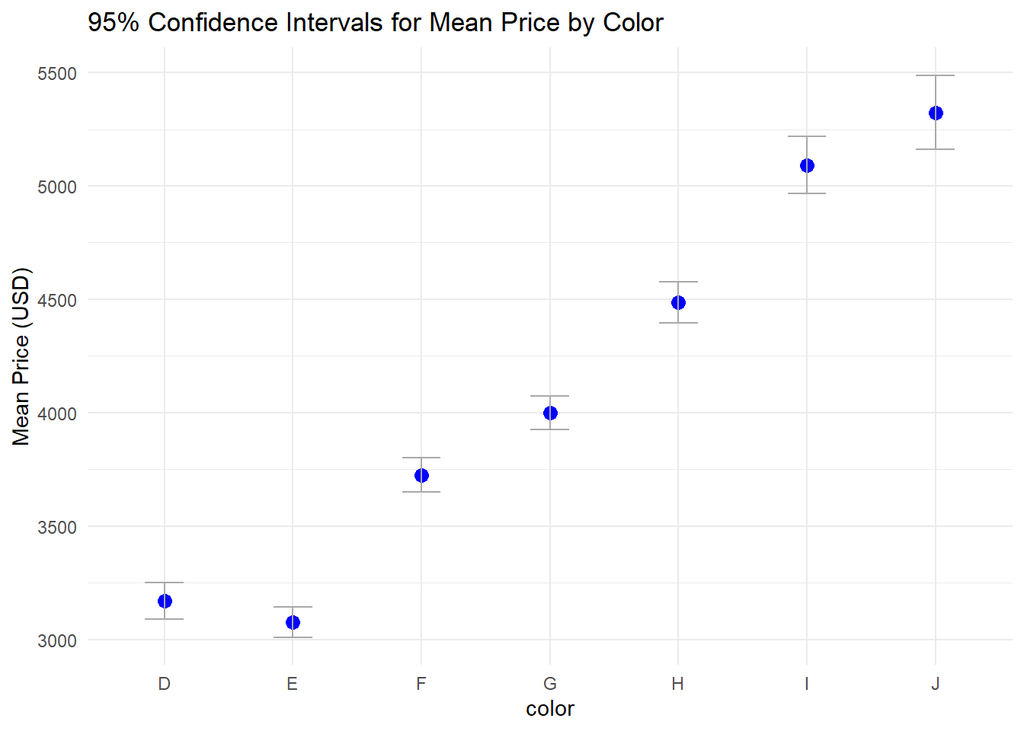

```r
# Plot confidence intervals for mean price by color
ggplot(color_ci, aes(x = color, y = mean_price)) +
  geom_point(size = 3, color = "blue") +
  geom_errorbar(aes(ymin = lower_ci, ymax = upper_ci), width = 0.3, color = "darkgray") +
  ggtitle("95% Confidence Intervals for Mean Price by Color") +
  ylab("Mean Price (USD)") + theme_minimal()
```

The graph shown above is a visualization of the mean price by color with a 95% confidence interval.

```r
# Function for two-sample z-test
z_test <- function(mean1, mean2, sd1, sd2, n1, n2) {
  se_diff <- sqrt((sd1^2 / n1) + (sd2^2 / n2))
  z <- (mean1 - mean2) / se_diff
  p <- 2 * pnorm(-abs(z))  # two-tailed p-value
  return(c(z_score = z, p_value = p))
}
```

The function shown about is used for the two-sample z-test. for the function, it takes as input the means, standard deviations, and sample sizes of both groups.

First, it calculates the standard error of the difference between the two means.

Then, it computes the z-score, which measures how far apart the sample means are in terms of standard errors.

Finally, it calculates the two-tailed p-value, representing the probability of observing such a difference (or more extreme) if the true means were equal. The function returns both the z-score and the p-value, allowing us to assess whether the difference between the two groups is statistically significant.

```r
# Compare all unique pairs of colors
color_pairs <- combn(color_ci$color, 2, simplify = FALSE)

# Run z-tests and collect results
z_test_results <- lapply(color_pairs, function(pair) {
  c1 <- filter(color_ci, color == pair[1])
  c2 <- filter(color_ci, color == pair[2])

  z_stats <- z_test(c1$mean_price, c2$mean_price, c1$sd_price, c2$sd_price, c1$n, c2$n)

  data.frame(
    Comparison = paste(pair[1], "vs", pair[2]),
    Z_Score = round(z_stats["z_score"], 2),
    P_Value = format(z_stats["p_value"], scientific = TRUE, digits = 2),
    Significant = ifelse(z_stats["p_value"] < 0.05, "Yes", "No")
  )
})
# Combine into a data frame and display
z_table <- do.call(rbind, z_test_results)
print(z_table)
```

```
##           Comparison Z_Score  P_Value Significant
## z_score       D vs E    1.76  7.8e-02          No
## z_score1      D vs F   -9.86  5.9e-23         Yes
## z_score2      D vs G  -14.85  6.6e-50         Yes
## z_score3      D vs H  -21.35 3.9e-101         Yes
## z_score4      D vs I  -25.29 4.3e-141         Yes
## z_score5      D vs J  -23.12 2.8e-118         Yes
## z_score6      E vs F  -12.61  1.9e-36         Yes
## z_score7      E vs G  -18.11  2.8e-73         Yes
## z_score8      E vs H  -24.61 9.7e-134         Yes
## z_score9      E vs I  -27.80 4.4e-170         Yes
## z_score10     E vs J  -24.88 1.2e-136         Yes
## z_score11     F vs G   -5.05  4.5e-07         Yes
## z_score12     F vs H  -12.62  1.6e-36         Yes
## z_score13     F vs I  -18.24  2.3e-74         Yes
## z_score14     F vs J  -17.33    3e-67         Yes
## z_score15     G vs H   -8.13  4.2e-16         Yes
## z_score16     G vs I  -14.65  1.4e-48         Yes
## z_score17     G vs J  -14.40  5.5e-47         Yes
## z_score18     H vs I   -7.65    2e-14         Yes
## z_score19     H vs J   -8.75  2.1e-18         Yes
## z_score20     I vs J   -2.20  2.8e-02         Yes
```

First, it generates all possible color pairs using combn().Then, for each pair, it filters the dataset color_ci to get the statistics (mean price, standard deviation, and sample size) for each color. It applies the previously defined z_test function to compute the z-score and p-value for the difference between their mean prices. The results—including the color comparison, z-score (rounded), p-value (formatted in scientific notation), and a significance flag indicating whether p < 0.05—are stored in a data frame.

Finally, it combines all results into a single table z_table and prints it, summarizing which color pairs have statistically significant price differences.

## Results

**Notable Statistics:** **95% confidence Intervals (USD)**:  
**D**: (3090.03, 3249.88)  
**E**: (3010.53, 3142.97)  
**F**: (3648.94, 3800.83)  
**G**: (3924.41, 4073.86)  
**H**: (4395.99, 4577.35)  
**I**: (4966.17, 5217.58)  
**J**: (5159.66, 5487.98)

Using a 95% confidence interval, we observe that diamonds with color grade J have a higher estimated mean price than other color grades, with the interval ranging from $5,159.66 to $5,487.98. We also notice that some color grades, such as D and E, have overlapping confidence intervals, indicating that their mean prices are not significantly different.